# Data Science Case Study

#### Introduction

An Indonesian micro-finance company entered into a partnership with a teleco provider to give clients access to micro loans which which can be used purchase mobile phone credit. Customers can take loan amounts of 5 or 10 rupiah and pay back 6 & 12 rupiah within 5 days of receiving the loans.  
One year into the partnership the finance company wants more information about the teleco's clients so it contracts a data science consulting firm D^3.

The client informs D^3 that they would like to segment the customers into meaningful risk profiles so they can tailor appropriate products for each cohort. The business also wants an interactive prediction App which can predict new client's risk profile and exisiting clients to see there risk profile chnages over time.

D^3 has defined the business problems into 2 questions. This allows to data scientists brainstorm what outputs will b require to help solve these business problems.

**Q1:** *Can clients be clustered into meaningful risk profiles using their credity history?*

Output: Create homogeneous cohorts with similar customer characteristics and different risk profiles.

**Q2:** *Once customer cohorts have been established can new/exisiting customers be assigned to a chort based on their recent mobile phone usage data?*

Output: label new clients cohorts by providing a user friendly shing app which can ingest new client data and output the new labels into a dynamic table or export to csv.

#### Exploratory data analysis

D^3 generally follows the data workflow as set out in Hadley Wickham's book "R For Data Science", most of the data transformations, cleansing & visualisation will be done using the Tidyverse which makes the inputs and outputs within the R environment more readable, stable and robust over time. The modelling part of the workflow would need to expand outside of the Tidyverse and this is also typical for most projects.

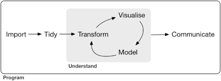

#### Data

The key target variable in this dataset is called "label" and it classifies customers who have or have not paid back their mobile phone loan credit within five day timeframe (1 == Yes, 0 == No).

The combination of mobile phone usage and a customers ability to repay credit will be used cluster customer into homogeneous cohorts so credit risk profiles can be assigned to each one.

Looking at this data a few things are very evident, first we have both bunch of count measures, quantitative stats (sums, median, max and average) and one usual categorical variable (the target variable). The methods used to produce the stated outputs expect that the data has the same or similar scale and that each variable is normally distributed. The later assumption is not critical for these methods but certainly simplify the process and just and important the interpretations of the end outputs.  
The next section will outline how the data was transformed to achieve these two underlying assumptions.

#### Log transformations

Its clear for looking at the first facet chart visualising each variables distribution that the variables are not normally distributed and have vastly different scales, to overcome this I applied a log transformation will be applied to the variables.

Looking at the second chart the scales similar and the distributions are much more normally distributed, other power transformations with optimisation may have yielded better results but one of the firm's key philosophies is simplicity first and complexity only when req4uired. Clearly there is also some outliers evident from this one visualises and the scales are still abit different but the next multivariant method called principal component analysis will help you with that.

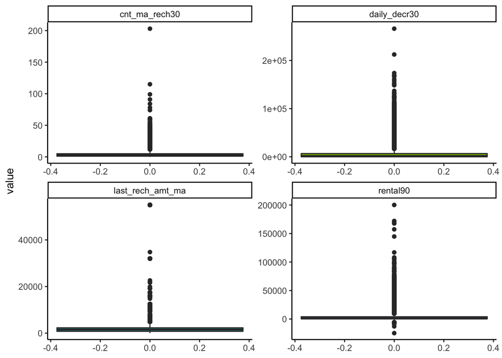

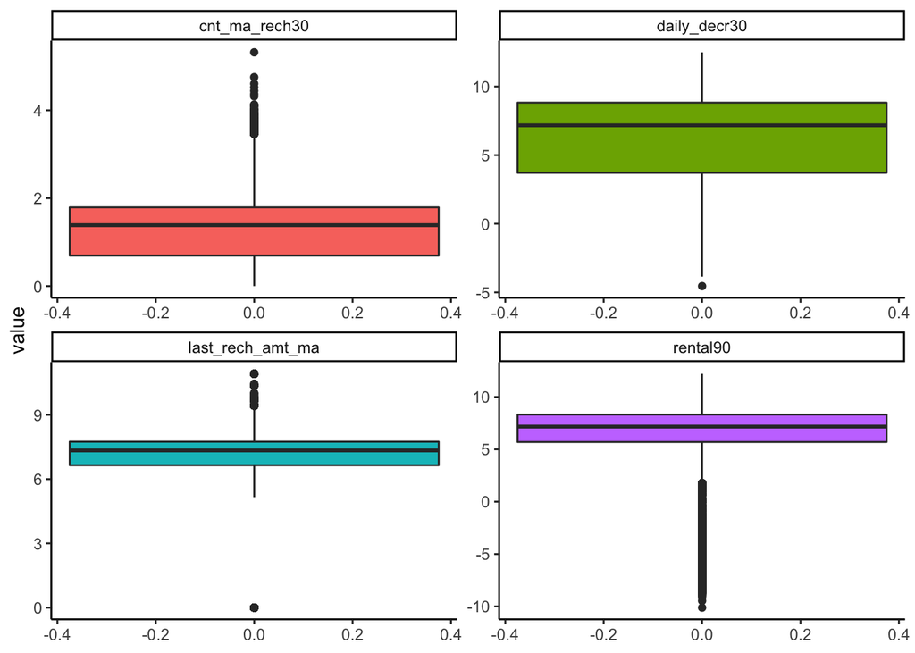

#### Removing variable multi-colinearity

There is another issue with this data that is not quite as evident when looking at individual distribution plot, that is that many of the variables will be highly correlated to one another. Typically, this is confirmed visually but just going off the data definitions alone makes it clear that this will be an issue as many of the measures are the same but with different time windows (30 & 90 days). It is gernally considered best practise to remove this collinearity as it will be very hard to separate which variables are providing the most information value and it is also a basic underlying assumption of most statistical models that it is not present across explanatory variables.

D^3 decided to use the Multi-variant technique called principal component analysis which converts the explanatory variable (minus target variable) into a series of orthogonal dimensions (remove collinearity) and has some added bonuses. This includes identifying which variables which are adding not real information’s value (enough variation to explain any variation in the target variable), reducing the dataset down to 10 dimensions (rather than 37 variable) whilst returning91.6% of the information value and finally the variable is cantered and scaled prior to PCA model creating the dimensions.

The result of this process can be seen below, it can be seen in the top graph that many of the log transformations variables were highly correlated to one another, after the PCA process the 10 dimensions are orthogonal to one another, that is the paired correlations between the variables is approximately equal to zero.

##### Correlation martix of log variables

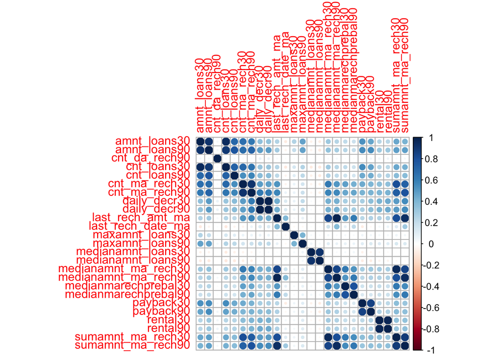

##### Correlation martix of PCA dimensions

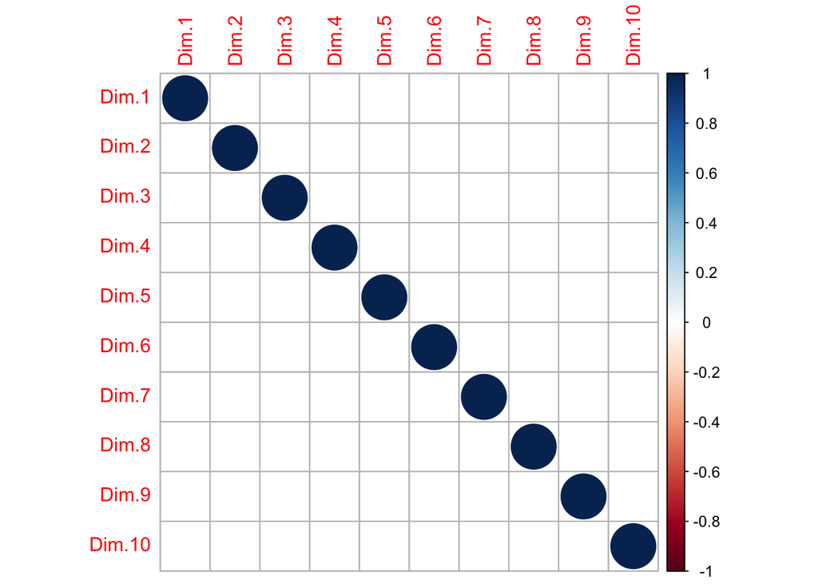

#### cluster PCA dimesions into meaningful risk profiles

Cluster modelling is a process of adding meaningful labels to data (unsupervised learning) so observations can be paired other observations with similar charactertics. In this case clients have been grouped together based on data usage, total loans taken, median data usage etc.

So each cohort could be label as such cluster 1 == "High value customer", cluster 2 == "Moderate value customer", cluster 3 == "Low value or new customer".

This is a big step forward for the finance company, we can now attach these new labels all all these mobile accounts captured in the 3-month window and new client moving forward. One of the interesting use cases of this info could be marketing strategy designed to transitioning appropriate clients from Moderate value users to the high value cohort which would generate more micro loans with higher probability of repayment for the firm.

###### Summary stats grouped by cluster

| clustering | proportion_credit_repaid | total_clients | percentage_total_clients |
| --- | --- | --- | --- |
| 1 | 96 | 89399 | 48 |
| 2 | 83 | 76250 | 41 |
| 3 | 54 | 20587 | 11 |

###### Histogram of 3 important variables startied by cluster

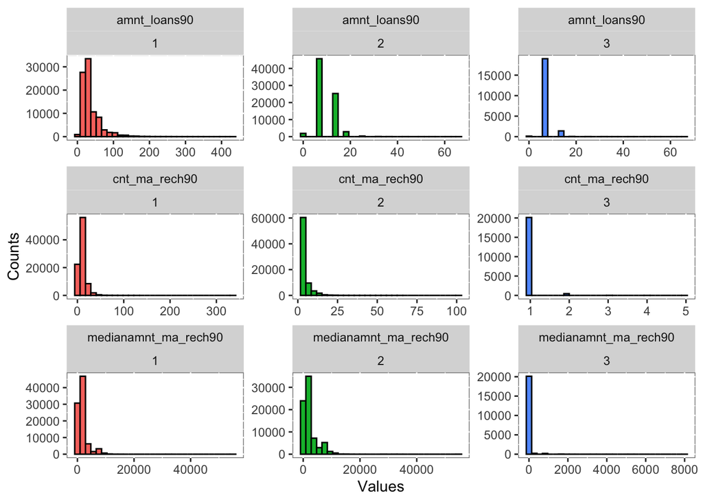

#### Prediction Apps

D^3 decide to use neural networks model because if typically does a great job of predicting multi-categorical response variables, particularly if they are very active cohorts. The below illustrates the accuracy of the model, leaving 10% of the data out for validation purposes it only misclassified one observation. It should be noted that for the model to remain this reboot and include new observations the same workflow converting the data into distinctive cluster would need to be redone (but this could be a simple task to click off in an Azure/AWS pipeline task or Shiny App).

```
##        Pred
## Actuals    1    2    3
##       1 8985    0    0
##       2    0 7608    1
##       3    0    0 2030
```

### Appendix

#### Sample of Teleco data with descriptions

| Var.Name | Sampe.1 | Sampe.2 | Sampe.3 | Sampe.4 | Sampe.5 | Desc |
| --- | --- | --- | --- | --- | --- | --- |
| label | 0 | 1 | 1 | 1 | 1 | Credit paid back within 5 days (1 == Yes, 0 == No.) |
| msisdn |  |  |  |  |  | Mobile Number |
| aon | 272 | 712 | 535 | 241 | 947 | Age of network |
| daily_decr30 | 3055 | 12122 | 1398 | 21 | 151 | Daily usage last 30 day |
| daily_decr90 | 3065 | 12125 | 1398 | 21 | 151 | Daily usage last 90 day |
| rental30 | 220 | 3691 | 900 | 159 | 1099 | Av rental balance last 30 days |
| rental90 | 260 | 3691 | 900 | 159 | 1099 | Av rental balance last 90 days |
| last_rech_date_ma | 2 | 20 | 3 | 41 | 4 | No. days since last recharge main acc |
| last_rech_date_da | 0 | 0 | 0 | 0 | 0 | No. days since last recharge data acc |
| last_rech_amt_ma | 1539 | 5787 | 1539 | 947 | 2309 | Amount of recharge in main account (indo Rupiah) |
| cnt_ma_rech30 | 2 | 1 | 1 | 0 | 7 | No. times acc was recharged last 30 days |
| fr_ma_rech30 | 21 | 0 | 0 | 0 | 2 | Free credit last 30 days |
| sumamnt_ma_rech30 | 3078 | 5787 | 1539 | 0 | 20029 | Total amount of recharges last 30 days |
| medianamnt_ma_rech30 | 1539 | 5787 | 1539 | 0 | 2309 | median amount recharged main account last 30 days |
| medianmarechprebal30 | 8 | 61 | 66 | 0 | 29 | Median account balance last 30 days |
| cnt_ma_rech90 | 2 | 1 | 1 | 1 | 8 | No. times acc was recharges last 90 days |
| fr_ma_rech90 | 21 | 0 | 0 | 0 | 2 | Free credit applied to account in last 90 days |
| sumamnt_ma_rech90 | 3078 | 5787 | 1539 | 947 | 23496 | Total amount of recharges last 90 days |
| medianamnt_ma_rech90 | 1539 | 5787 | 1539 | 947 | 2888 | median amount recharged main account last 90 days |
| medianmarechprebal90 | 8 | 61 | 66 | 3 | 35 | Median account balance last 90 days |
| cnt_da_rech30 | 0 | 0 | 0 | 0 | 0 | No. time data account recharged last 30 days |
| fr_da_rech30 | 0 | 0 | 0 | 0 | 0 | Free data last 30 days |
| cnt_da_rech90 | 0 | 0 | 0 | 0 | 0 | No. time data account recharged last 90 days |
| fr_da_rech90 | 0 | 0 | 0 | 0 | 0 | Free data last 90 days |
| cnt_loans30 | 2 | 1 | 1 | 2 | 7 | Number of loans taken last 30 days |
| amnt_loans30 | 12 | 12 | 6 | 12 | 42 | Summed loaned indo rupees last 30 days |
| maxamnt_loans30 | 6 | 12 | 6 | 6 | 6 | Max loan amount last 30 days |
| medianamnt_loans30 | 0 | 0 | 0 | 0 | 0 | Median loans amounts last 30 days |
| cnt_loans90 | 2 | 1 | 1 | 2 | 7 | No. of loans taken last 90 days |
| amnt_loans90 | 12 | 12 | 6 | 12 | 42 | Summed loaned indo rupees last 90 days |
| maxamnt_loans90 | 6 | 12 | 6 | 6 | 6 | Max loan amount last 90 days |
| medianamnt_loans90 | 0 | 0 | 0 | 0 | 0 | Median loans amounts last 90 days |
| payback30 | 29 | 0 | 0 | 0 | 2 | Av payback time last 30 days |
| payback90 | 29 | 0 | 0 | 0 | 2 | Av payback time last 90 days |
| pcircle | UPW | UPW | UPW | UPW | UPW | Teleco provider |
| pdate | 20/7/2016 | 10/8/2016 | 19/8/2016 | 6/6/2016 | 22/6/2016 | Phone activation date |